## 1. Introduction

The main purpose of trading is buying and selling stocks, bonds, or other financial instruments with increasing the returns of the investments in mind while maintaining relatively low risk. With the help of a trading strategy, an investor can try to improve his performance. One can simply divide the strategies into passive and active. The praised and well established passive strategy buy-and-hold takes no short price movements into account. Positioning and trading based on these short price movements are considered active trading.

This paper applies time-series analysis to these short price movements to create active trading strategies. The objective of these developed strategies is to outperform the buy-and-hold strategy.

### 1.1. Data Analysis

The dataset which will be analyzed in this paper contains 4 tradeable indexes, a visualization of the data is shown below in figure .

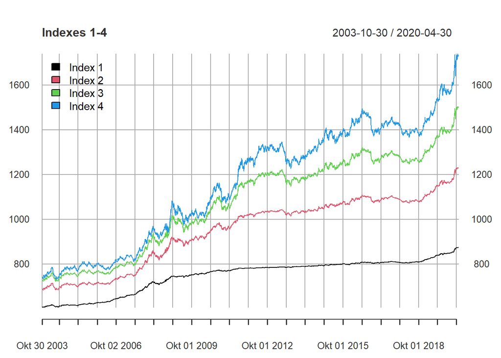

Visualization of the 4 indexes

Each time-series has 4306 observations and starts from October 2003 to April 2020. In all indexes is an upward drift observable, during the time period of the great recession (2008) is a slight bump visible. Also later in 2013 and 2016 are small break-ins evident. More interesting is the up and down behavior at the end of the series during the Covid19 pandemic.

In addition, to the indexes, the dataset contains 8 different interest rates of treasury bonds which will be used for further analysis. A few key-values of the interest rates are shown in the following table .

Summary of the 8 interest rates.

|  | Maturity | Mean | Volatility | Min. | Max. |
| --- | --- | --- | --- | --- | --- |
| Interest 1 | 3M | 4.09 | 4.95 | -0.28 | 16.27 |
| Interest 2 | 6M | 4.47 | 5.05 | 0.01 | 16.73 |
| Interest 3 | 1Y | 4.64 | 4.22 | 0.20 | 10.51 |
| Interest 4 | 2Y | 5.42 | 4.58 | 0.49 | 16.58 |
| Interest 5 | 3Y | 6.16 | 4.33 | 0.75 | 16.51 |
| Interest 6 | 5Y | 7.41 | 3.82 | 1.06 | 16.44 |
| Interest 7 | 7Y | 9.50 | 3.31 | 1.71 | 16.63 |
| Interest 8 | 10Y | 11.61 | 2.93 | 3.13 | 17.47 |

A typical characteristic of interest rates is shown in the given data. A bond with longer maturities is often associated with higher returns compared with those with shorter maturities. An investor which invests in short-term treasury bonds will have his gain earlier but will be confronted with a lower return.

A more in depth analysis of the given dataset will follow in section 3.1.

### 1.2. Ojective of this paper

The objective of this paper is to trade these 4 indexes with an active trading strategy. The main objective is to outperform the passive buy-and-hold strategy. Methods such as the Moving-Average-Filter or the ARMA-GARCH-Model provide signals for either long or short the position to maximize the return of the investments in these indexes.

The performance of these strategies are build open various different parameters and conditions. The lengths of the filters applied to a Moving-Average may result in different solutions. Models could perform differently for any given length of the in-sample or out-of-sample scope. The necessity of including a historical crisis in the starting-sample can decide if a model performs better or worse than another. The correct validation of model parameters could have a significant impact on the forecasts.

In addition to all criteria and conditions, the strategies can be further adjusted by composing different weighted portfolios. Estimated predicted volatility can be used to modulate the position size to mitigate the risk.

Challenging will be finding the most optimal model in this wide field of conditions and parameters. The buy-and-hold strategy will be used as a benchmark to be compared with the developed active trading strategies. Computing and comparing the Sharpe ratios of each model can serve as an indicator to rely on for better or worse models.

## 2. Theory

It is assumed that the reader of this paper already has basic knowledge of the mathematical principles of time series analysis. Therefore, this section will only briefly describe the mathematical models and processes.

### 2.1. Time-Series

Almost anything with a data point to a given timestamp can be named a time-series. The monthly gross domestic product, the weekly US gasoline production, or daily stock price movements. In this paper lies the focus of the analysis of financial time series. Due to trades often only take place during the week, there are gaps in the time series on the weekends, an exception would be the trading of cryptocurrencies like Bitcoin which are also tradeable at the weekends.

A series of data points with more or less equidistant time points $t$ with the sample length of $T$, is called a time-series $x_{t}, t=1,...,T$ [@eco1]. The analysis of a time-series $x_{t}$ involves creating a reasonable model that can be utilized to perform forecast predictions.

#### 2.1.1. Stationarity

In order to fit a suitable model with a given time series $x_{t}$, the assumptions of stationarity must be met. In this practical application, only the following weak-stationarity properties are required.

$$\begin{equation}
\label{eq:mean}
E[x_{t}]=\mu
\end{equation}$$

$$\begin{equation}
\label{eq:var}
Var(x_{t})=\sigma_{x}^{2}
\end{equation}$$

$$\begin{equation}
\label{eq:cov}
Cov(x_{t}, x_{t-k})=R(k)
\end{equation}$$

Many financial time-series are subject to shift, trends or changing volatility. In figure are the stock prices of Alphabet Inc Class A (Google) visualized. This time-series shows a clear upwards drift and towards the end the volatility increases.

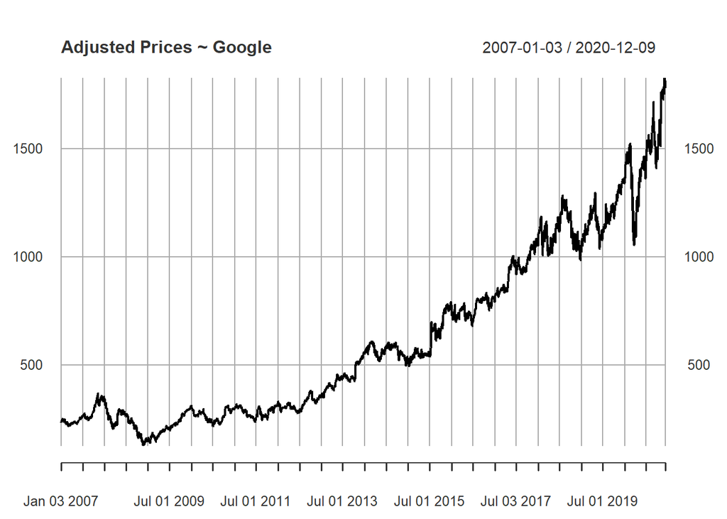

Visualization of the adjusted prices of the Alphabet Inc Class A Stock.

To improve the violated properties the first difference can be applied and additionally a logarithmic transformation can be performed [@slide_eco3_1]. The log-returns transformation can only performed to strict positive data.

$$\mathrm{LogReturn} = \mathrm{log}(x_{t})-\mathrm{log}(x_{t-1})$$

The result is the so-called log-returns.

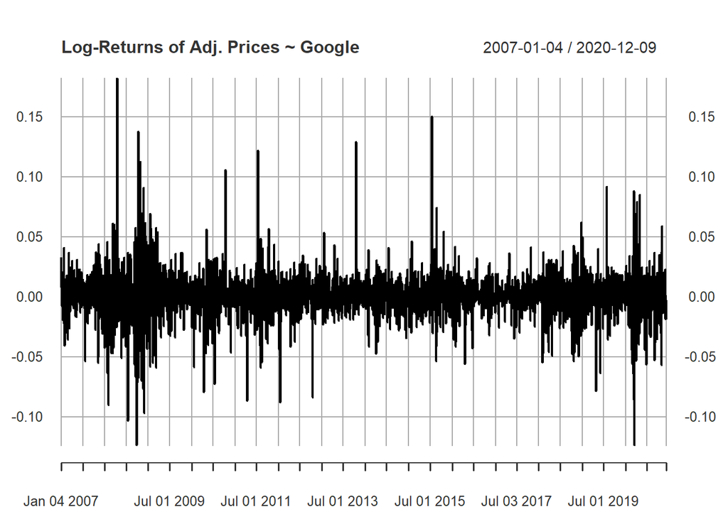

Visualization of the Log-Returns

Applying the transformation to the data causes the drift to disappear, but the series still contains stronger and weaker volatile phases. This effect often occurs in non-stationary financial data and is called volatility cluster. This special property is used for the modeling of forecast models, which will be discussed in chapter 2.2.

In the following examples, we will only work with a section of the time series, as it often makes no sense to look long into the past. The further a value lies in the past, the smaller its influence on a future value will be.

#### 2.1.2. Autocorrelation

The autocorrelation function (ACF) reveals how the correlation between any two data points of the time series changes as their separation changes [@acf]. More precisely, acf measures the dependence between $x_{t}$ and $x_{t \pm k}$ at lag $k$. The partial autocorrelation (PACF) measures the dependency between $x_{t}$ and $x_{t-k}$ at lag $k$ [@eco1]. For stationary time series, ACF can be used to identify the model order of a MA-process, PACF for AR-processes.

In the following figure are ACF and PACF of the non-stationary adjusted Google stock visualized. Both graphics show the typical pattern of a non-stationary time series. The plot above shows the dependence structure of the time series. This means that it takes a long time until the series changes. Often a large value is followed by another large value, which indicates a strong trend. This property of the series can be seen in figure as the long upward drift. The plot below indicates a significant partial autocorrelation at lag $k=1$.

In the following section 2.2. the characteristics of the autocorrelation function can be used for the verification of ARIMA and ARCH-processes.

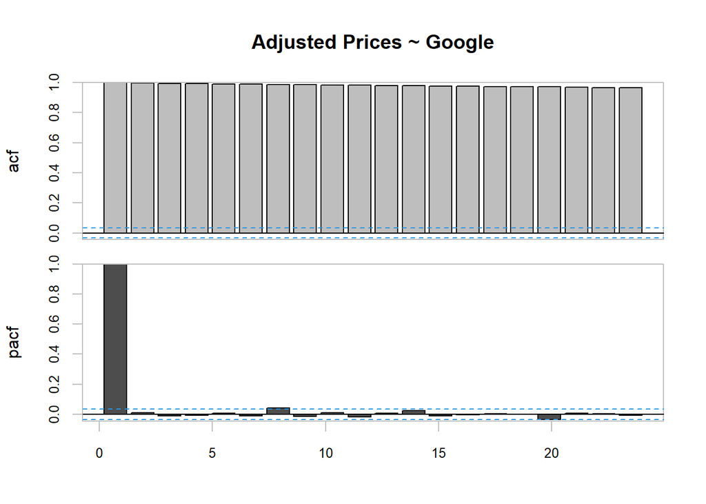

Acf and Pacf of the Adjusted Prizes of Google.

### 2.2. Models

The following processes are used to determine certain properties and characteristics of a time series so that they are transformed into a model. The goal is to fit the time series as well as possible in order to create reliable forecasts.

#### 2.2.1. ARIMA

An ARIMA(*p*,*d*,*q*) process is defined as follows.

$$\begin{equation} \label{eq:arima}
x_{t}=c+a_{1}x_{t-1}+...+a_{p}x_{t-p}+\epsilon_{t}+b_{1}\epsilon_{t-1}+...+b_{q}\epsilon_{t-q}
\end{equation}$$

- $p$ and $q$ are the AR- and MA-model orders
- $a$ and $b$ are the AR- and MA-model parameters
- $d$ is the differential parameter
- $\epsilon_t$ is a white noise sequence
- $x_t$ is the given data $x_{1},...,x_{T}$

The mean of an ARIMA-process can be computed as:

$$\mu=\frac{c}{1-a_{1}-...-a_{p}}$$

ARIMA processes can be divided into 4 different models. Choosing a model that best represents the time series is a difficult task. The goal is to find the best possible model with as few parameters as possible.

The previously introduced ACF and PACF can help to determine the orders of simple models. Provided that the time series is stationary, the model orders can be determined directly. For an AR(*p*)-process (ARIMA(*p*,*0*,*0*)), the ACF plot will gradually decrease and simultaneously the PACF should have a sharp drop after *p* significant lags. For an MA(*q*)-process (ARIMA(*0*,*0*.*q*)) the opposite is true, the ACF should show a sharp drop after a certain *q* number of lags while PACF should show a gradual decreasing trend. If both ACF and PACF show a gradual decreasing pattern, then the ARIMA(*p*,*0*,*q*)-process should be considered for modeling [@arima]. If the time series is not stationary, differentiation can be considered (ARIMA(*p*,*d*,*q*)).

The application of an analysis method to Google prices finds an ARIMA(*1*,*1*,*0*) as the optimal model. This makes sense if you look back at figure . Long dependency structures in the ACF plot indicating an AR(*p*) process and at the same time after lag=$1$=*p* the PACF has a strong drop. The differential operator *d*=$1$ transforms the non-stationary series into a stationary one.

To convince yourself of the quality of the model, you can use the Ljung-Box statistics shown in figure . For the lags where the p-values are above the 5% line, the forecasts are reliable. Here the values from the 6 lag are below the significant line, but since one only wants to make short-term forecasts (for example 1 day into the future), the lag is sufficient up to 5. If you want to forecast further than 5 days into the future, you might have to adjust the ARIMA model.

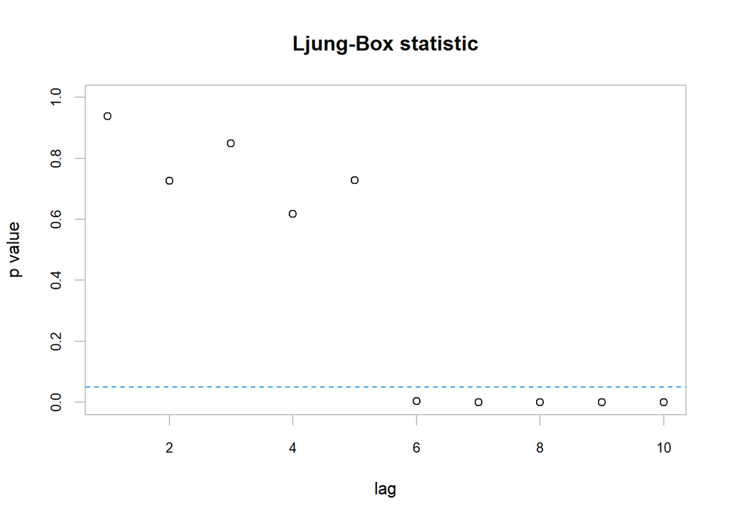

Ljung-Box statistic of Google log returns.

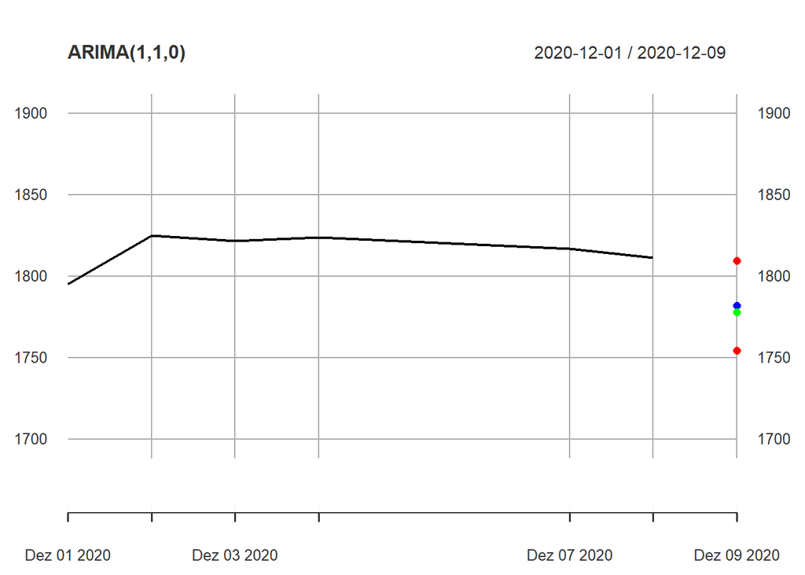

ARIMA-Forecast.

#### 2.2.2. GARCH

The volatility clustering mentioned in section 2.1.1 can be handled with an generalized auto-regressive conditional heteroscedastic process.

$$\begin{align} \label{eq:garch}
\epsilon_{t} &= \mathrm{log}(x_{t})-\mathrm{log}(x_{t-1}) \nonumber \\
\epsilon_{t} &= \sigma_{t}u_{t} \\
\sigma_{t}^{2} &=c \sigma^{2}+\sum_{j=1}^{n}\alpha_{j}\sigma_{t-j}^{2}+\sum_{k=1}^{m}\beta_{k}\epsilon_{t-k}^{2} \nonumber
\end{align}$$

with

- $x_{t}$ is the original data (often non-stationary)
- $\epsilon_{t}$ is the stationary log-return
- $u_{t}$ is independent and identically distributed (iid) and a standardized random variable
- $\sigma^{2}$ is the unconditional variance of the process $\epsilon_{t}$.
- $\sigma_{t}^{2}$ is the conditional variance of the process $\epsilon_{t}$.

With a GARCH(*n*,*m*)-process it is possible to model the volaclusters of a time series. The GARCH(*1*,*1*) model has become widely used in financial time series modeling and is implemented in most statistics and econometric software packages. Those models are favored over other stochastic volatility models by many economists due to their relatively simple implementation [@garch11].

For an optimal model some conditions must be fulfilled. Suppose you want to model the Google time series with a GARCH(*1*,*1*).

The following parameter restrictions are also examined:

$$\begin{equation} \label{eq:para_restriction}
c+\sum_{j=1}^{n}\alpha_{j}+\sum_{k=1}^{m}\beta_{k}=1
\end{equation}$$

with

$$c>0, \alpha_{k}\geq0, j=1,...,n, \beta_{k}\geq0, 1,...,m$$

To satisfy formula , $c$ needs to be determined from $\omega$. First calculate the unconditional variance.

$$\sigma^{2} = \frac{\omega}{1-\alpha_{1}-\beta_{1}}$$

Calculate $c$ with:

$$c=\frac{\omega}{\sigma^{2}}$$

and then check for the restriction in .

For the coefficients of GARCH(*1*,*1*) the restrictions are fulfilled. You can see that $c = 1-\alpha_{1}-\beta_{1}$. So this restriction can be determined easily with:

$$\begin{equation} \label{eq:para_moments_easy}
\sum_{j=1}^{n}\alpha_{j}+\sum_{k=1}^{m}\beta_{k} < 1
\end{equation}$$

If the parameter restrictions are not fulfilled, complications may arise, the forecast of the conditional variance $\hat{\sigma}^{2}_{t}$ may diverge to the unconditional variance $\sigma^{2}$ of the process.

Furthermore, the Ljung-Box statistics are important for the standardized residuals. Looking back at formula standardized residuals $u_{t}$ are proportional to the conditional volatilities $\sigma_{t}$, which should lead to the log returns $\epsilon_{t}$. The conditional volatilities map the volacluster in the time series. To achieve the best possible model, one does not want to find these volacluster effects in the standardized residuals, but only in the conditional volatilities. The Ljung-Box statistics check this property. In figure Ljung-Box statistics of the $\hat{u}_{t}$ and the $\hat{u}^{2}_{t}$ are shown.

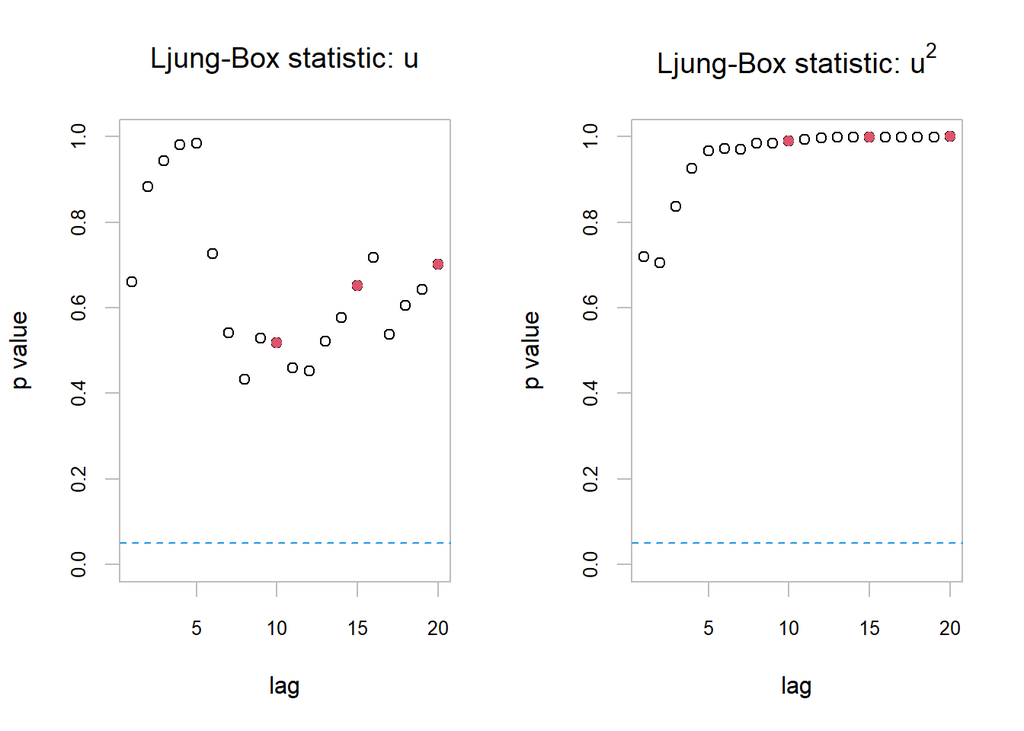

Ljung-Box statistic of the standardized residuals.

The plot shows reliable statistics for forecasts from the Google-GARCH(*1*,*1*) model. For all lags up to 20, the p-values are above the 5% line and thus hypothesis tests are discarded. However, if for a given lag=k the p-values would fall below the 5% line, then forecasts would only be reliable up to a forecast horizon k.

If one wants to improve the the standardized residuals $\hat{u}_{t}$ (if autocorrelations exists in the $\hat{u}_{t}$), an ARMA part would have to be added to the existing model (see 2.2.3). This can again be optimized with different model orders. If you want to improve the squared standardized residuals $\hat{u}^{2}_{t}$ (if volaclustering exists within the $\hat{u}^{2}_{t}$), then you should modify the GARCH model order.

Now an optimal model has been found and a forecast can be made. Since a GARCH(*n*,*m*) process is white noise sequence the expected value $E[\epsilon_{T+h} | \epsilon_{T},...,\epsilon_{1}]=\mu=0$ can be assumed (if the mean value in the fit object was also estimated and is significant, then the expected value is the estimated $\mu$).

Calculating the forecast variance is a recursive process. With increasing model order the calculation becomes more and more difficult. For this work the rather simple calculation for a GARCH(*1*,*1*) model is sufficient. One receives:

$$\hat{\sigma}_{T+h}^{2}=\omega+(\alpha_{1}+\beta_{1})^{2}\hat{\sigma}_{T+h-1}^{2}$$

If the parameter restriction from formula is true, the forecast variance converges with the increasing forecast horizon to the unconditional variance of the process.

$$\hat{\sigma}_{T+h}^{2}=\frac{\omega}{1-\alpha_{1}-\beta_{1}}=\sigma^{2}$$

The 95% forecast interval is calculated as follows:

$$E[\epsilon_{T+h} | \epsilon_{T},...,\epsilon_{1}]\pm 1.96\sqrt{\hat{\sigma}_{T+h}^{2}}$$

Figure shows the GARCH(*1*,*1*) forecast for 20 days. The blue line represents the expected value of the time series. Reds are the two 95%-interval limits and green shows the actual values of the series.

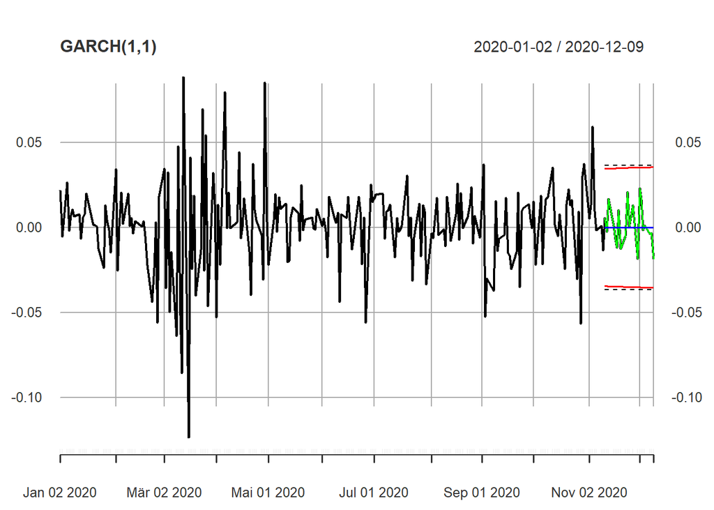

GARCH-Forecast.

You can see how the red lines are approaching the black dotted lines ($0 \pm 1.96*\sqrt{\sigma^{2}}$) as the forecast horizon increases. This means that the forecast variance converges to the unconditional variance and thus there is another proof for the satisfaction of the parameter restrictions.

#### 2.2.3. ARMA-GARCH

If you want to adopt a GARCH model and you discover non-vanishing autocorrelations in the standardized residuals $\hat{u}_{t}$, the model can be extended with an ARMA part to counteract the autocorrelations.

$$\begin{eqnarray}
y_{t}&=&\mu + a_{1}y_{t-1}+...+a_{p}y_{t-p}+\epsilon_{t}+b_{1}\epsilon_{t-1}+...+b_{q}\epsilon_{t-q} \label{eq:arma-garch1} \\
\epsilon_{t}&=&\sigma_{t}u_{t} \nonumber \\
\sigma_{t}^{2}&=&c\sigma^{2}+\sum_{j=1}^{n}\alpha_{j}\sigma_{t-j}^{2}+\sum_{k=1}^{m}\beta_{k}\epsilon_{t-k}^{2} \label{eq:arma-garch2}
\end{eqnarray}$$

This model contains now 4 different model orders: *p*,*q*,*n* and *m*. Experience shows that for financial time series, a model order of *n*=*m*=$1$ and *p*,*q*$\leq 1$ is often sufficient to fit the data to an ARMA-GARCH model.

The equation is called the *mean-equation* and describes the conditional mean of the process, which is used to obtain optimal point forecast. The equation defines the variance of the process and is called *variance-equation*, which is used for the forecast error variance [@eco2].

#### 2.2.4. M-GARCH

The last model that is considered as a forecast model in this thesis is the so-called MGARCH model. Highly volatile phases indicate downturns. Market participants tend to oversell during these downturns. Overselling leads to inflated volumes and this in turn leads to inflated volatilities. This model can be helpful since it emphasizes recession and crisis dynamics.

$$\begin{align} \label{eq:mgarch}
r_{t} &= \mathrm{log}(x_{t})-\mathrm{log}(x_{t-1}) \nonumber \\
r_{t} &= \mu+e\sigma_{t}+\epsilon_{t} \\
\epsilon_{t} &= \sigma_{t}u_{t} \nonumber
\end{align}$$

where

- $x_{t}$ is the original data (typically non-stationary)
- $r_{t}$ are the log-returns (stationary)
- $\mu$ is the long-term drift
- $\epsilon_{t}$ is a volacluster process (GARCH)
- $e$ is a constant (a parameter to be estimated), $e>0$ implies a larger expected return. $e<0$ would imply a smaller expected return. If $e=0$ then the MGARCH-effect vanishes [@slide_eco3_3].

For this model, the in-sample conditional standard deviations (volatilities) from any GARCH process are determined and the out-of-sample conditional standard deviation for obtaining forecasts of the future returns is then calculated by regression.

$$\hat{r}_{t+1}=\hat{\mu}+\hat{e}\hat{\sigma}_{t+1}$$

### 2.3. Moving Average Filters

Moving average filters are basically used to identify trends and smooth out price fluctuations. As a commonly used tool, moving average filters are very simple in their usage, historical data from a timeframe L gets summarized and divided by the length of the filter (L). Depending on the length of the filter, the application to the timeseries the MA gets shifted, longer filters have a higher shift then shorter ones we visualize this behavior in . Many different indicators are built upon the Moving Average principle, mostly they are used in combinations of different lengths to create signals. In the following section, we introduce some of the most popular indicators based on the MA principle.

The actual challenge in using Moving average filters, is to figure out which length of the filter brings the most useful information.

#### 2.3.1. Equally-weighted Moving Average or SMA

SMA stands for Simple Moving Average, depending on the length of the filter(L), L observations since the last noted observation will be considered. The observations are getting summarized and divided by the filterlength L. As stated in the name, all past observations are weighted equally. For every timestep, a new observation is considered and the last one eliminated [@SMA]. SMA’s are very easily customized by changeing the length of the filter.

EqMA

$$\begin{equation}
\label{eq:eqma}
y_{t}=\frac{1}{L}\sum_{k=0}^{L-1}x_{t-k}
\end{equation}$$

- ${L}$ = filterlength
- ${x}$ = original series price e.g.

##### 2.3.1.1 Momentum

Momentum is an indicator wether a market is bullish or bearish, it measures the “speed” of the trend direction in the market. for a timespan $k$ the last price $p_k$, $k$ timesteps ago is subtracted from the last price. This is equivalent to applying and EqMA on the returns of a series.

Momentum

$$\begin{equation}
\label{eq:momentum}
y_{t}=p_t - p_{t-K}
\end{equation}$$

- ${p_t}$ = prices of the series
- ${K}$ = Lag

#### 2.3.2. Exponentially-weighted Moving Average

Since not all observations are having the same influence on the future value, we can apply a weight to past observations. One method will be exponentially weighted Moving average. So we chose an optimal parameter to give past observations weights decreasing by $\alpha^{k}$. In comparison to the SMA 2.3.1. [@EMA] ,a EMA from the same length L, reacts faster than to price changes.

A skillful trader chooses an optimal $\alpha$ to increase the performance of the measurement. Weights could also be given individually by adding a weight vector to the filter.

EMA

$$\begin{equation}
\label{eq:ema}
y_{t}=\frac{1}{\sum_{k=0}^{m}\alpha^{k}}\sum_{k=0}^{m}\alpha^{k}x_{t-k}
\end{equation}$$

- ${m}$ = filterlength
- ${\alpha}$ = Parameter to weigh the observations

#### 2.3.3. Moving Average Crossings

Moving average crossings are basically just different MA’s with different lengths applied to a time-series. The points the filters then cross, will be used as a trading signal to go long, short or hold. The “death” and “golden” cross are very popular trading patterns [@EMA]. If a shorter MA crosses the longer MA from above, its called a “golden cross” it is an indicator that the price will rise in the future and can be used to created the buy signal. In contrast stands the “death cross” vise versa, a shorter MA (popular L = 50) crosses a longer MA(popular L = 200) from below, signalizing that further losses are in store.

Moving Average Crossing

$$\begin{equation}
\label{eq:mac}
y_{t}=\frac{1}{L_1}\sum_{k=0}^{L_1-1}x_{t-k} - \frac{1}{L_2}\sum_{k=0}^{L_2-1}x_{t-k}
\end{equation}$$

- ${L_1}$ = filterlength 1
- ${L_2}$ = filterlength 2
- ${0 < \alpha < 1}$ = Parameter to weigh the observations

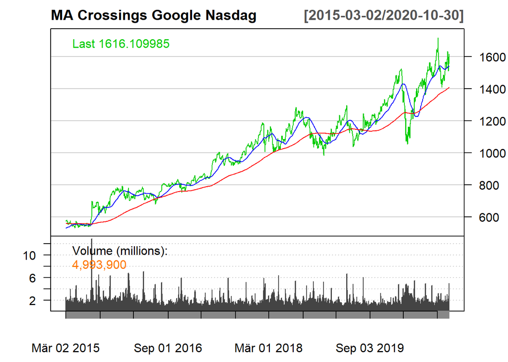

Moving Average Crossing

### 2.4. Relative Strength Index

The Relative strength index is a tool to measure momentum, the value indicates if positions are overvalued or undervalued. the scale goes from 0 to 100. [@slide_trading_indicators_univariate].

$$\begin{equation}
\label{eq:mac1}
U_{t}=\begin{cases}1, \textnormal{if } x_t \ge x_{t-1}\\0, \textnormal{otherwise} \end{cases}
D_{t}=\begin{cases}1, \textnormal{if } x_t < x_{t-1}\\0, \textnormal{otherwise} \end{cases}
\end{equation}$$

- ${X_t}$ =Original timeseries

We then apply SMA or EMA of length N to $U_t$ and $U_t$ which converts them in $up_t(N)$ and $down_t(N)$ The RSI is now computet by:
$$\begin{equation}
\label{eq:mac2}
RSI_t(N)=100\frac{up_t(N)}{up_t(N)+down_t(N)}
\end{equation}$$

The original developer J. Welles Wilder Jr. proposed a length of N =14 in its work from 1978 [@RSI]. Traditional tradings signals based on the RSI are the upper 70 or lower 30 limit to buy or sell. Usually when the RSI is going over 70 it suppose that the asset is overvalued and in contrast when its under 30 then its undervalued.

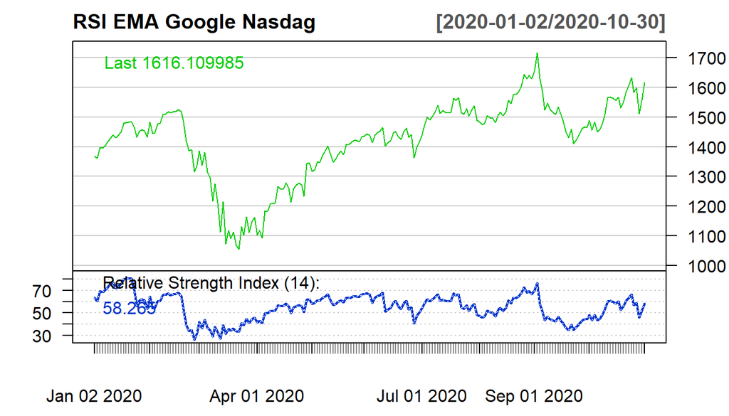

RSI

### 2.5. Moving Average Convergence Divergence

The MACD is also a commonly used filter. The basic principle is to Subtract a longer EMA with length $L$ as in section 2.3.3 from a shorter EMA from length $S$ then smooth the result with another EMA with length $R$. As a result with can use the crossing of the 2 generated curves for trading. As an alternative we could use SMA’s instead of EMA’s

$$\begin{equation}
\label{eq:MACD}
\mathrm macd_t =\frac{1}{\sum_{k=0}^{t-1}\alpha^{k}} \sum_{k=0}^{t-1}\alpha^{k}x-{t-k}-\frac{1}{\sum_{k=0}^{t-1}\beta^{k}}\sum_{k=0}^{t-1}\beta^{k}x-{t-k}
\end{equation}$$

$$\begin{equation}
\label{eq:signal MACD}
\mathrm MACD signal_t= \frac{1}{\sum_{k=0}^{t-1}\gamma^{k}}\sum_{k=0}^{t-1}\gamma^{k}x-{t-k}
\end{equation}$$

- $x_t$ = prices or log prices
- $S$ = length of the $short_1$ EMA usually 12
- $L$ = length of the $long_1$ EMA usually 26
- $R$ = length of the “double smoothing ema” usually 9
- $\alpha$ = $1-\frac{1}{S}$, $\beta$ = $1-\frac{1}{L}$, $\gamma$ = $1-\frac{1}{R}$

$_1$ short and long in the meaning s<l, not buy sell

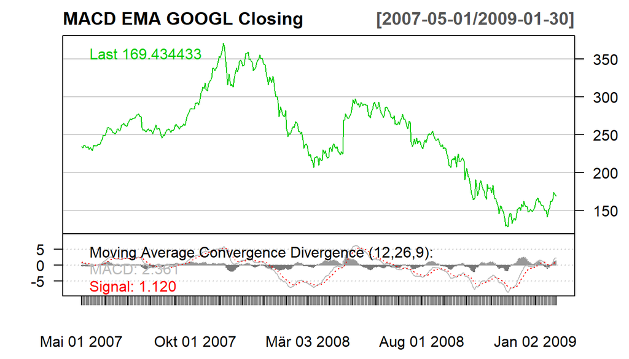

MACD

### 2.6. Bollinger bands

Bollinger bands are a analysis tool founded by John Bollinger. It contains a moving average and an upper and lower band . The bands are defined by adding a constant ${K}$ times a standard deviation ${\sigma_t}$ to the *Moving Average* for the upper , and subtracting it for the lower band.

$$\begin{equation}
\label{eq:lower and upper bollingerbands}
\mathrm{U_t}=MA_{t}+K\sigma, L_{t}=MA_{t}-K\sigma
\end{equation}$$

the variance from bollingers theory is calculated by:

$$\begin{equation}
\label{eq:variance bollingerbands}
\mathrm{\sigma_{t}^2}=\frac{1}{N}\sum_{k=0}^{N-1}(x_{t-k} -MA_t)^2
\end{equation}$$

The calculated ${\sigma_t}$ could be problematic because its derived from the original series and increases with the level, its non stationary. Therefore an other method to calculate the standard deviation could be used. As done in section 2.2.2. $\sigma_t$ could be provided by a GARCH, which would handle the increasing volatility.

- ${N}$ = usually the filterlength and the length considered for ${\sigma}$ are the same
- ${K}$ = Constant usually equals 2
- $\sigma_p$ = standard deviation of the series
- ${U_t}$ = upper band
- ${L_t}$ = lower band

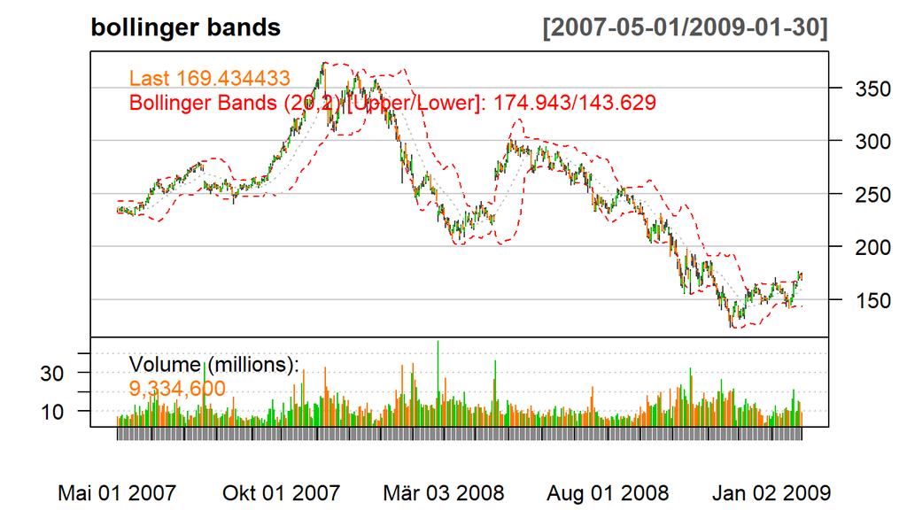

Bollinger Bands

### 2.7. Performance Indicators

#### 2.7.1. Sharpe Ratio

Sharpe ratio is a very powerful and widely used ratio to measure performance. It describes return per risk.

$$\begin{equation}
\label{eq:Sharperatio}
\mathrm{SharpeRatio}=\frac{R_{p}-R_{f}}{\sigma}
\end{equation}$$

- ${R_p}$ = Return of Portfolio
- ${R_f}$ = Risk free Rate, mostly treasury bonds
- ${\sigma_p}$ = standard deviation of portfolios excess return (risk)

For comparing different series often the sharpe ratio is annualized with $\sqrt{250}$ and the ${R_f}$ is considered 0.

#### 2.7.2. Drawdown

Drawdown describes the maximum cumulated loss an investor is going to face if he isnt leaving a falling market at the turning point from rise to fall of an index.

$$\begin{equation}
\label{eq:Maximum Drawdown}
\mathrm{MDD}=\frac{\textnormal{bottomvalue}-\textnormal{peakvalue}}{\textnormal{peakvalue}}
\end{equation}$$

Maximum drawdown is used as an indicator for risk or can be used as an optimization criterion[@Maxdrawdown].

### 2.8. Carry

Carry trades are trading strategies were usually money is borrowed at a lower interest rate, than the investment is giving in return. the risk of this strategy is based in the currency risk.

## 3. Methodology

In this section, different models are created and compared with the buy and hold strategy. You start with pure data analysis and then work your way from simple models to more and more complex ones.

### 3.1. Data Analysis

As mentioned in section 1.1 we are now going to analyze the data further to gain as much information as possible just by using some simple tools and comparisons.

#### 3.1.1. Correlation

One could nearly tell just by looking at the indexes how strong they’re correlated. The correlation matrix in table confirms the assumption, the correlation is nearly 1 for every index to each other.

Correlations oft the four indexes

|  | Index 1 | Index 2 | Index 3 | Index 4 |
| --- | --- | --- | --- | --- |
| Index 1 | 1.0000000 | 0.9899111 | 0.9788826 | 0.9672956 |
| Index 2 | 0.9899111 | 1.0000000 | 0.9975499 | 0.9921171 |
| Index 3 | 0.9788826 | 0.9975499 | 1.0000000 | 0.9983460 |
| Index 4 | 0.9672956 | 0.9921171 | 0.9983460 | 1.0000000 |

#### 3.1.2. transformation, volatility and clusters

Applying the natural logarithm to the series is an approach to cancel out increasing volatility . The strong upward drift is still visible, the original series has more than doubled to its original price over the whole timespan (index 4) .

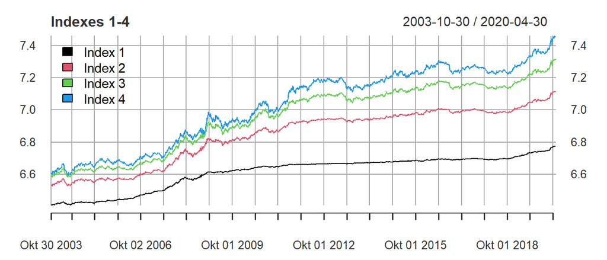

Visualization log indizes

By taking the returns of the transformed series we can visualize volatility clusters as seen in figure . The first value of the series is eliminated because of the differences, Clearly visible are the high spikes in the times of the financial crisis 2007-2009. Also at the end of the series, the impact of COVID19 in march 2020 is remarkable.

Sharpe Ratio and Volatility of the 4 indexes (log-returns).

|  | Index 1 | Index 2 | Index 3 | Index 4 |
| --- | --- | --- | --- | --- |
| Volatility | 0.0008 | 0.0020 | 0.0029 | 0.0039 |
| Sharpe-Ratio | 1.6710 | 1.0601 | 0.9143 | 0.7922 |

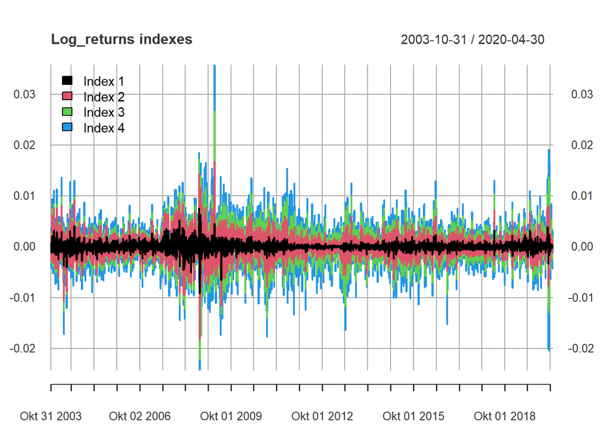

Log returns

##### 3.1.2.1. Autocorrelation of log returns

By computing the ACF of the squared log-returns we see that the volatility cluster has very long dependency structures.

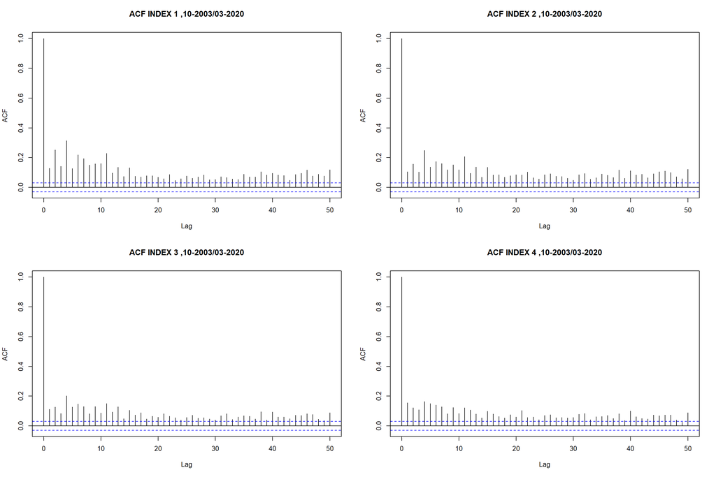

ACF log returns

For further analysis, we concentrate on different timespans, because in most models it makes little sense to consider the whole time-series from 2003 till today.

### 3.2. Trading

In section 2 we have learned different indicators and models for time-series-analysis. Some of these models and indicators are now used to trade the indexes we’ve introduced in the previous section.

To do so we need to create trading signals based on the models and indicators. For example, we are using the MA Crossings, as mentioned 2.3.3. the points where the two MAs cross, are now used to create a trading signal. when the longer MA comes from below to the crossing we are going long the asset and if it approaches the point from above we’re shorting the position. Technically we apply a 1 to a vector at each crossing, where we intend to buy and apply a -1 at the points we want to sell.

#### 3.2.1. Buy and Hold Performance

As mentioned earlier the goal of this work is trying to outperform the buy and hold strategy. Because the series all have a strong upward trend this task is very tricky. Buy and hold has very low trading costs because the underlying is just bought once. According to swissquote [@swissquote] costs for asset trades over 50k, are 190 USD per trade $_1$, so these costs should also be taken into consideration for choosing the strategy. In this work, we’ve excluded these costs and only concentrate on the trades themselves.

$_1$ notice: This fee is only for private investors, conditions may differ for institutions.

For the following models a good comparability should be achieved. To ensure this, all models are created with the same out-of-sample range, with the start date 2019-01-01.

##### 3.2.1.1. Portfolios

By focussing on trading we build a portfolio for the 4 indexes. One approach would be the equally weighted portfolio with weights for every index of $\frac{1}{4}$. As we’ve seen in figure The volatility of the indexes strongly differs, meaning that index 4 would have the most impact, nearly 50 %, on the portfolio by weighing it equally. To cancel this effect, it may be useful to size the position with the inverse volatility, so the indexes have the weights seen in the table on the right side.

$$\begin{equation}
\label{eq:standardizing vola}
procentual share \sigma_k = \frac{\sigma_k}{\sum_{k=1}^{4}\sigma_k}
\end{equation}$$

shares

|  | percentage of vola when equally weighted | weights when weigthed with inverse vola |
| --- | --- | --- |
| Index 1 | 3.70980 | 70.246503 |
| Index 2 | 16.15568 | 16.130577 |
| Index 3 | 31.55567 | 8.258436 |
| Index 4 | 48.57885 | 5.364485 |

### 3.3. AR trading

As with the theory data set, these 4 indexes are non-stationary series. For the AR models, the stationary log-returns of the time series are used. First we look at index 1, the series with the lowest volatility but with the highest sharpe ratio (highest return with lowest risk). To find the best possible AR model, different AR(*p*) models are fitted with different model orders *p* for different in-sample ranges. The parameters *p* and start date are so called hyper parameters, parameters which are set before modelling. For each model the out-of-sample sharpe is calculated. The execution of this calculation leads to the solution shown in table .

Solution of the AR-Model calculation.

| StartDate | AR-Sharpe | p | \| | StartDate | AR-Sharpe | p |
| --- | --- | --- | --- | --- | --- | --- |
| 2003-01-01 | 3.296 | 1 | \| | 2011-01-01 | 2.004 | 3 |
| 2004-01-01 | 3.037 | 1 | \| | 2012-01-01 | 1.852 | 3 |
| 2005-01-01 | 3.146 | 1 | \| | 2013-01-01 | 2.033 | 4 |
| 2006-01-01 | 2.957 | 1 | \| | 2014-01-01 | 1.954 | 3 |
| 2007-01-01 | 2.722 | 1 | \| | 2015-01-01 | 1.932 | 5 |
| 2008-01-01 | 1.867 | 1 | \| | 2016-01-01 | 3.449 | 2 |
| 2009-01-01 | 2.473 | 1 | \| | 2017-01-01 | 2.163 | 4 |
| 2010-01-01 | 2.651 | 1 | \| | 2018-01-01 | 3.765 | 2 |

With these calculations, the optimal model is an AR(2) with the start date 2018-01-01. Note that the Index 1 series has a very flat rising trend and a rising upward trend towards the end of 2018, so only a short in-sample is needed for this optimal model. It is interesting that the long in-sample ranges (2003 to 2007) also lead to relatively good performances. This probably has something to do with the fact that trend at the beginning of the series has a greater influence on the model than the middle part.

[figure not shown]

Visualization of the optimal AR(2)-Model.

The upper part of figure shows the optimal model compared to buy and hold. The AR(2) has a higher sharpe than buy and hold. Regarding performance, it should be mentioned that the sharpe optimization of the algorithm is based on daily trades. The signals for a trade are newly generated with each daily forecast and could lead to high trading costs (positive signals = long, negative signals = short).

The lower part of figure shows the trading signals visually. If one were to trade exactly according to the AR(2) forecasts, one would make a trade at each vertical line, a total of 111 trades would have to be made during out-of-sample periods. If you want to include trading costs in the performance, an AR model with daily trades would have to be much better than this one to outperform buy-and-hold.

But what influence do the trading costs really have? If you assume a fictitious investment amount of 1 million USD and you have to pay 190 USD for each trade, as mentioned in section 3.2.1. Invest this amount at the beginning of the out-of-sample period. With the buy-and-hold strategy, a return of USD 63832 is achieved by the end of the out-of-sample range. Without trading costs the AR(2) would yield USD 68130, with trading costs only USD 47040. To get at least the same return on the investment, the trading costs should not exceed USD 39. Note that in addition to the trading costs, the initial investment amount also matters.

Thus it can be said that for index 1, the buy-and-hold strategy cannot be outperformed by an AR(2) model. Nevertheless, one would like to apply this procedure also to the other indexes, possibly the generated models perform better for the other time-series.

Optimal AR-Models.

|  | StartDate | AR-Sharpe | p | B&H-Sharpe | Trades |
| --- | --- | --- | --- | --- | --- |
| Index 1 | 2018-01-01 | 3.765 | 2 | 3.505 | 111 |
| Index 2 | 2004-01-01 | 3.100 | 1 | 2.476 | 19 |
| Index 3 | 2005-01-01 | 2.528 | 1 | 2.155 | 21 |
| Index 4 | 2003-01-01 | 2.218 | 1 | 1.945 | 9 |

Table shows the solutions of all 4 indexes. The algorithm finds an optimal AR model with model order 1 for all 3 remaining time-series. In contrast to index 1, it is noticeable that a much longer in-sample range is required for the optimal model. This also makes sense because the indexes show an increasing trend during the complete in-sample range. Index 1 is less volatile and has a less strong trend compared to the others, so a strong increase in the trend (spring 2018) has a greater effect on model performance. The other 3 series are more volatile, have larger peaks and therefore the model performance is less influenced by single events (like the increasing trend in spring 2018). The number of trades is much smaller for all models than for the first one. The out-of-sample performances are better than the corresponding buy-and-hold performances for all AR models.

Because of the trading costs, it has been seen with index 1 that the AR model, despite better performance, generates a lower return than buy-and-hold. But what about the other indexes. You choose the same investment amount and trading costs as before and you get the following table .

Out-of-Sample Returns.

|  | Buy & Hold | AR without tradingcost | AR with tradingcost |
| --- | --- | --- | --- |
| Index 1 | 63832 | 68130 | 47040 |
| Index 2 | 106055 | 131723 | 128113 |
| Index 3 | 143291 | 167284 | 163294 |
| Index 4 | 184657 | 209858 | 208148 |

Despite the trading costs, daily trading with the indexes 2-4 generates a higher return than the passive buy and hold strategy.

Figure shows the out-of-sample performance of the second index. Right at the beginning of the series, the AR model signals a trade (one goes short and immediately long again). This trade immediately leads to an increase in performance which already outperforms the passive strategy. Further signaled trades will only occur again later. During the Corona crisis (spring 2020), one can see several close consecutive trades. The volatility increases sharply during this period, the AR model catches this event well and remains positive.

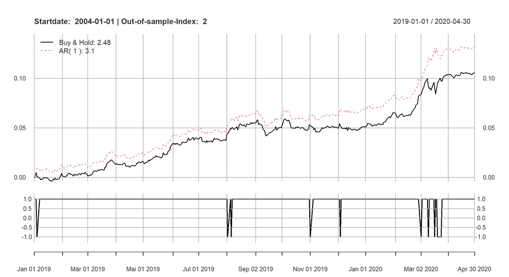

Visualization of the optimal Index 2 AR(1)-Model.

The optimal AR model for the third index shows almost the same behavior as index 2 (as seen in figure ), the only difference being an additional trade in spring 2019.

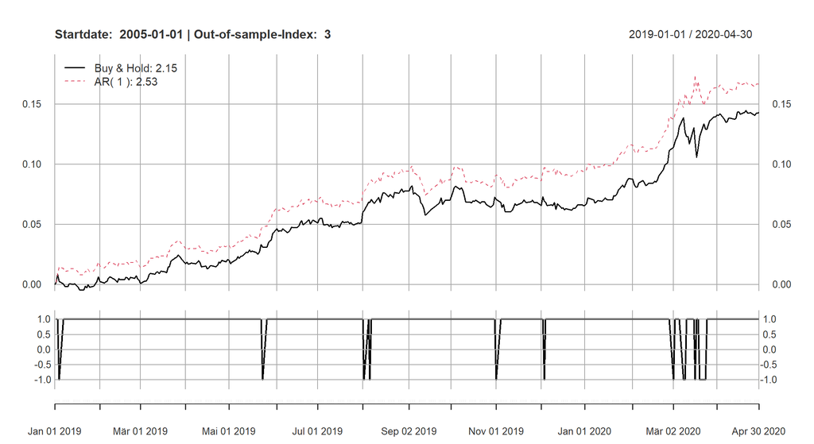

Visualization of the optimal Index 3 AR(1)-Model..

The fourth index, which is shown in the lower figure , is interesting again. The optimal AR model predicts almost the same behavior as buy-and-hold for almost the entire duration. Only during the highly volatile phase of the Corona crisis are the same trades listed as for index 2 and 3.

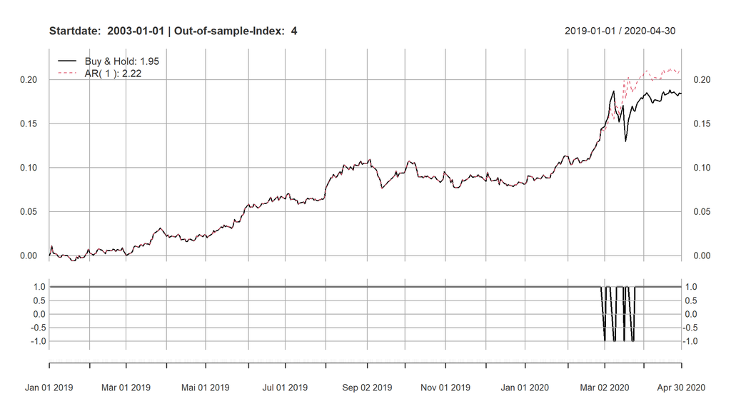

Visualization of the optimal Index 4 AR(1)-Model.

So it can be said that with very simple autoregressive models, a tool has been found with which it is possible to outperform the popular buy-and-hold strategy. Consider that this is only the case in this example with defined conditions. Depending on how high the trading costs and the amount of investment are, the returns can vary greatly. In addition to the buy-and-hold strategy, where you only buy and hold, you have to trade effectively with an active trading strategy.

### 3.4. Single Simple Moving average trading

Next thing to look at is the optimization with a single simple moving average. For AR models, the start date is a hyperparameter, as is the model order *p*. For SMA models there is no model order but a filter length *L*. The filter length is limited to:

$$5<L<500$$

Additionally the in-sample range is varied again. For each start date the in-sample performances are calculated for each filter length in the interval $5<L<500$. The AR model was only limited to the performance indicator sharpe ratio. This time we’re adding the Drawdown and MSE indicators. Thus, for each start date, for each filter length *L*, the three different indicators are calculated and an optimal model can be choosen.

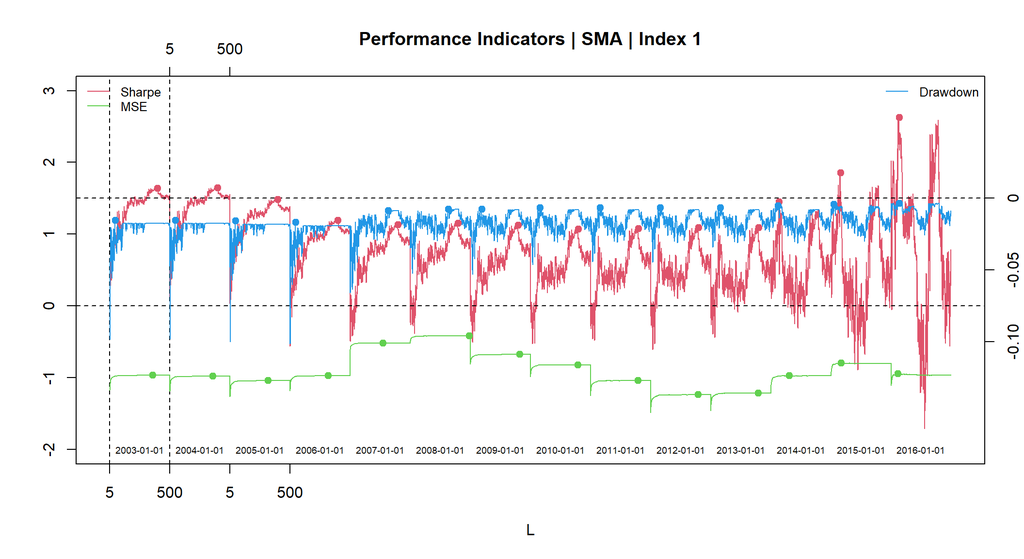

Optim

SMA-Optima by performance indicators | Index 1

| StartDate | Sharpe | L_Sharpe | Drawdown | L_Drawdown | MSE | L_MSE |
| --- | --- | --- | --- | --- | --- | --- |
| 2003-01-01 | 1.64 | 395 | -0.016885 | 47 | -0.965 | 356 |
| 2004-01-01 | 1.64 | 395 | -0.016766 | 47 | -0.977 | 356 |
| 2005-01-01 | 1.48 | 395 | -0.017368 | 47 | -1.038 | 314 |
| 2006-01-01 | 1.19 | 395 | -0.018482 | 47 | -0.970 | 315 |
| 2007-01-01 | 1.13 | 395 | -0.009597 | 315 | -0.516 | 271 |
| 2008-01-01 | 1.15 | 395 | -0.008487 | 316 | -0.418 | 486 |
| 2009-01-01 | 1.12 | 395 | -0.008263 | 95 | -0.676 | 409 |
| 2010-01-01 | 1.07 | 395 | -0.007125 | 81 | -0.820 | 393 |
| 2011-01-01 | 1.08 | 395 | -0.007129 | 81 | -1.039 | 393 |
| 2012-01-01 | 1.09 | 395 | -0.007124 | 81 | -1.236 | 393 |
| 2013-01-01 | 1.09 | 395 | -0.007143 | 81 | -1.212 | 393 |
| 2014-01-01 | 1.45 | 68 | -0.005884 | 59 | -0.972 | 153 |
| 2015-01-01 | 1.86 | 79 | -0.004819 | 24 | -0.798 | 83 |
| 2016-01-01 | 2.63 | 69 | -0.003817 | 69 | -0.947 | 56 |

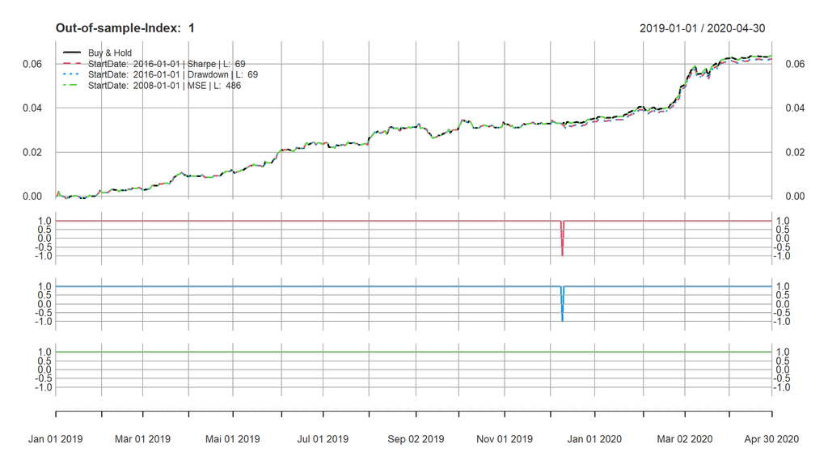

Best

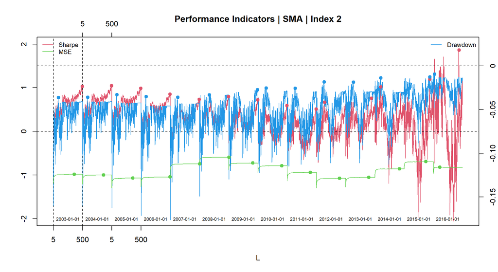

Optim

SMA-Optima by performance indicators | Index 2

| StartDate | Sharpe | L_Sharpe | Drawdown | L_Drawdown | MSE | L_MSE |
| --- | --- | --- | --- | --- | --- | --- |
| 2003-01-01 | 1.03 | 492 | -0.039010 | 86 | -0.984 | 356 |
| 2004-01-01 | 1.04 | 492 | -0.038522 | 86 | -0.997 | 356 |
| 2005-01-01 | 0.99 | 492 | -0.035429 | 86 | -1.068 | 356 |
| 2006-01-01 | 0.85 | 492 | -0.037649 | 86 | -1.045 | 491 |
| 2007-01-01 | 0.73 | 492 | -0.038677 | 127 | -0.744 | 500 |
| 2008-01-01 | 0.79 | 492 | -0.035709 | 167 | -0.593 | 500 |
| 2009-01-01 | 0.72 | 492 | -0.029269 | 487 | -0.726 | 409 |
| 2010-01-01 | 0.59 | 492 | -0.027305 | 138 | -0.787 | 403 |
| 2011-01-01 | 0.51 | 492 | -0.027542 | 138 | -0.940 | 393 |
| 2012-01-01 | 0.67 | 139 | -0.019760 | 132 | -1.076 | 393 |
| 2013-01-01 | 0.76 | 436 | -0.019920 | 132 | -1.051 | 393 |
| 2014-01-01 | 1.02 | 101 | -0.014730 | 101 | -0.856 | 417 |
| 2015-01-01 | 1.20 | 436 | -0.013729 | 436 | -0.693 | 370 |
| 2016-01-01 | 1.86 | 436 | -0.010118 | 22 | -0.818 | 109 |

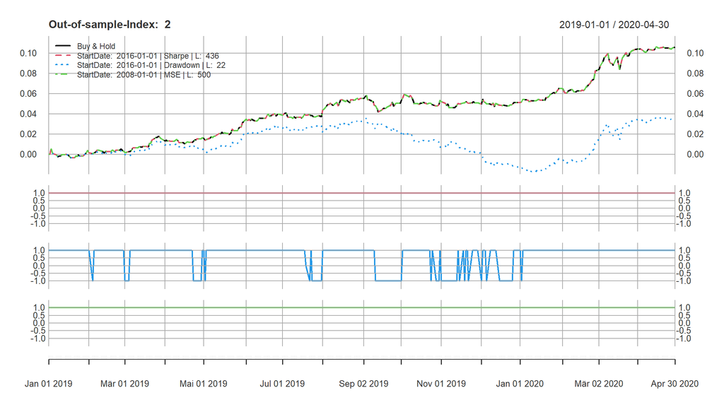

Best

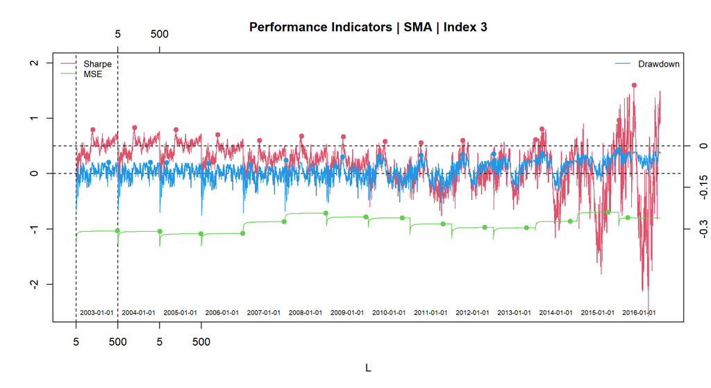

Optim

SMA-Optima by performance indicators | Index 3

| StartDate | Sharpe | L_Sharpe | Drawdown | L_Drawdown | MSE | L_MSE |
| --- | --- | --- | --- | --- | --- | --- |
| 2003-01-01 | 0.79 | 197 | -0.060662 | 386 | -1.036 | 491 |
| 2004-01-01 | 0.83 | 197 | -0.060434 | 386 | -1.045 | 500 |
| 2005-01-01 | 0.79 | 197 | -0.061444 | 85 | -1.087 | 491 |
| 2006-01-01 | 0.70 | 197 | -0.063696 | 85 | -1.080 | 491 |
| 2007-01-01 | 0.60 | 197 | -0.069731 | 85 | -0.870 | 489 |
| 2008-01-01 | 0.68 | 199 | -0.053510 | 16 | -0.715 | 489 |
| 2009-01-01 | 0.66 | 199 | -0.040467 | 193 | -0.783 | 469 |
| 2010-01-01 | 0.58 | 199 | -0.036689 | 132 | -0.801 | 403 |
| 2011-01-01 | 0.56 | 131 | -0.035098 | 131 | -0.908 | 393 |
| 2012-01-01 | 0.60 | 131 | -0.032591 | 131 | -0.973 | 393 |
| 2013-01-01 | 0.61 | 500 | -0.029062 | 6 | -0.977 | 393 |
| 2014-01-01 | 0.80 | 81 | -0.027517 | 81 | -0.862 | 417 |
| 2015-01-01 | 0.96 | 500 | -0.021496 | 474 | -0.697 | 370 |
| 2016-01-01 | 1.59 | 186 | -0.013063 | 10 | -0.798 | 109 |

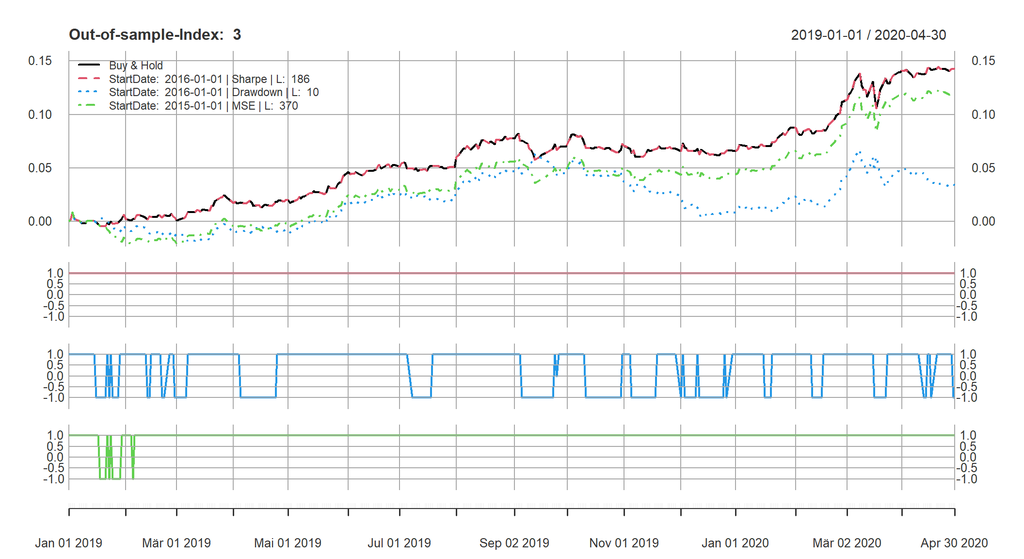

Best

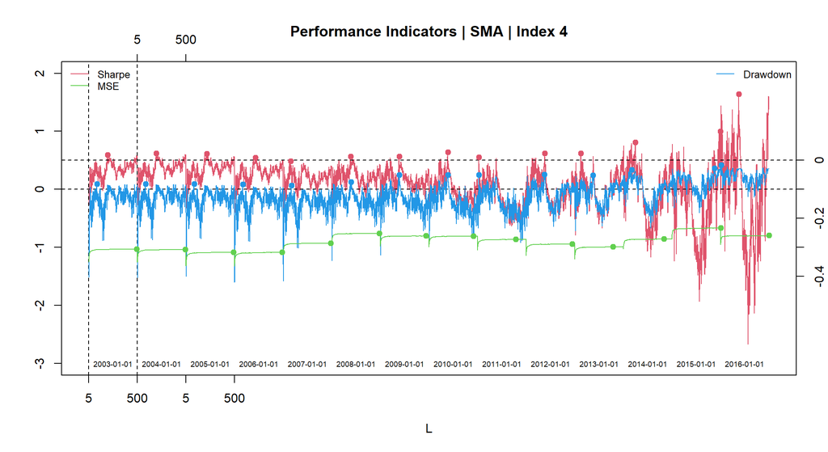

Optim

SMA-Optima by performance indicators | Index 4

| StartDate | Sharpe | L_Sharpe | Drawdown | L_Drawdown | MSE | L_MSE |
| --- | --- | --- | --- | --- | --- | --- |
| 2003-01-01 | 0.59 | 196 | -0.081763 | 87 | -1.030 | 489 |
| 2004-01-01 | 0.62 | 196 | -0.082296 | 87 | -1.038 | 489 |
| 2005-01-01 | 0.61 | 214 | -0.082023 | 87 | -1.087 | 489 |
| 2006-01-01 | 0.55 | 214 | -0.082992 | 87 | -1.088 | 489 |
| 2007-01-01 | 0.49 | 78 | -0.087710 | 87 | -0.928 | 489 |
| 2008-01-01 | 0.56 | 196 | -0.074848 | 199 | -0.760 | 489 |
| 2009-01-01 | 0.56 | 196 | -0.050453 | 194 | -0.805 | 469 |
| 2010-01-01 | 0.63 | 196 | -0.051127 | 194 | -0.809 | 457 |
| 2011-01-01 | 0.55 | 18 | -0.051190 | 18 | -0.864 | 393 |
| 2012-01-01 | 0.62 | 193 | -0.049622 | 188 | -0.943 | 471 |
| 2013-01-01 | 0.62 | 66 | -0.051850 | 188 | -0.992 | 393 |
| 2014-01-01 | 0.81 | 126 | -0.033376 | 88 | -0.857 | 417 |
| 2015-01-01 | 1.00 | 496 | -0.027309 | 435 | -0.669 | 500 |
| 2016-01-01 | 1.64 | 189 | -0.017155 | 9 | -0.799 | 497 |

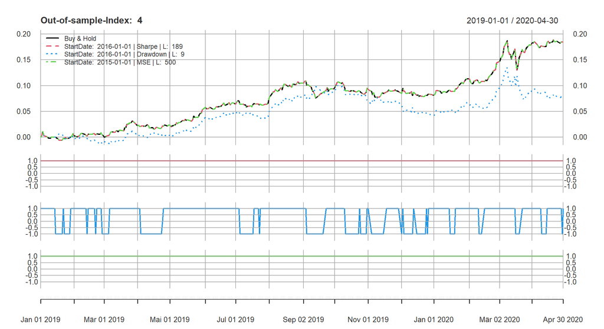

Best

### 3.5. Moving average crossings trading

As a third approach we apply 2 SMAs on every time series and trade them with the common Ma crossings rules introduced in 2.3.3.. With an optimaztion we’re trying to find the best filterlengths for the 2 SMA’s.

#### 3.5.1. Optimization

For the Optimization the same procedure as in the previous sections gets executed.

The optimization has two levels, the “first level” or outer level is narrowing the insample timespan from (2003-01 / 01-2019) to (01-2018 / 01-2019). In the inner level “second level” the real optimization is calculated by finding the optimal combination of filters, regarding maximum sharpe and maximum drowndown trading them with the common crossing trading rules.

Hyperparameter:

- $\textnormal{date}$ = startdate for the insample timespan $\textnormal{2003-01-01} < \textnormal{date} \le \textnormal{2018-01-01}\textnormal{, by 1 trading year}$

Parameters$_2$:

- $L1$ = length of shorter SMA with $1 < L1 \le 50$
- $L2$ = length of longer SMA with $100 < L1 \le 250$

Figure visualizes one iteration of the optimization. For the fixed L1 =1, L2 is variable and the optimal sharpe is calculated. This procedure is done for every filterlenght as described in $_2$ and further visualized in . The drawdown is also calculated as seen in plot . Notice that the visualization is from the starting date 2015-10-30, which is randomly chosen for explaining the optimization process.

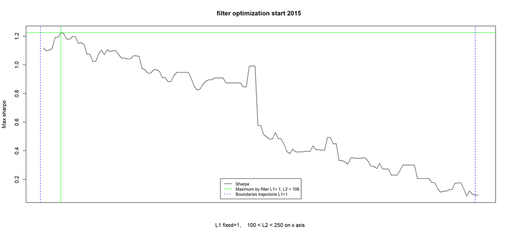

optimization sharpe L1=1 ,L2 = variable

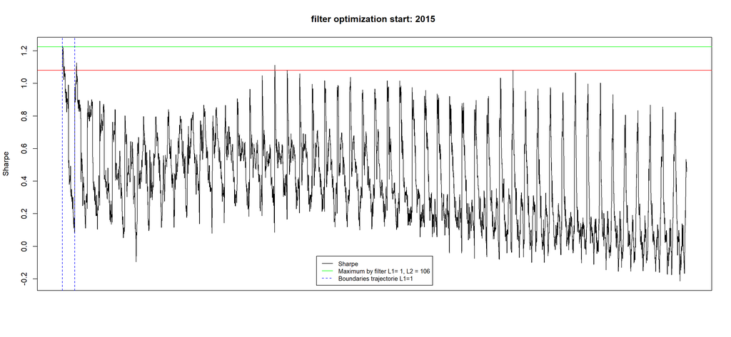

sharpe index 1

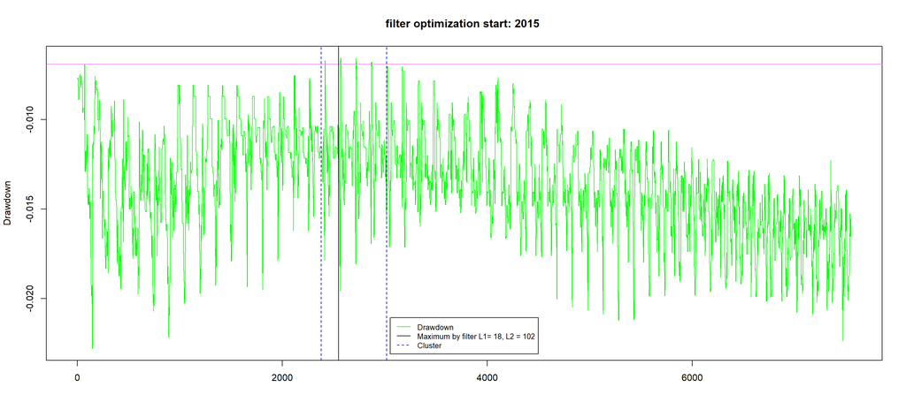

drawdown index 1

The pattern we observe in is the repeating optimization by fixing L1 and vary L2. The maximum sharpe was found with L1= *1*, L2= *106*, sharpe = *1.225*,which is also visualized in ,where the “window” (blue dottet lines) is shown. When we look at the red line we can clearly see there are other similar high spikes in other filter lengths. The green pattern in shows interesting news. at L1 = 17,18, 19 and 20 we see a cluster(blue dottet lines) of high spikes, all very similar. The optimum in this plot is by L1 = *18* and L2 = *102* and a drawdown *6.55e-3*, laying in the described cluster . But when we look at the violet line drawn, we can clearly see there’s another high spike at the beginning of the plot. This spike is identical with the maximum sharpe in . So theses results could just be random and the solution is not finite , this problem will be further discussed$_3$.

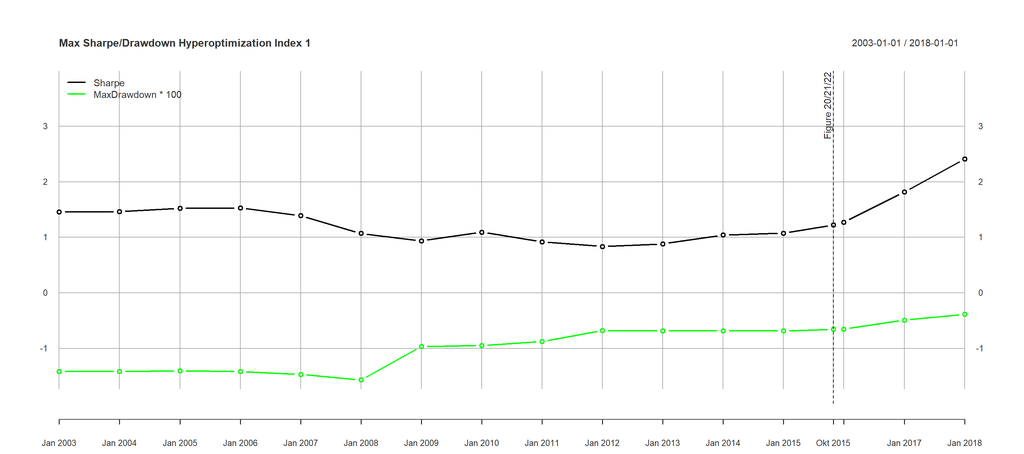

Hyperoptimization Index 1

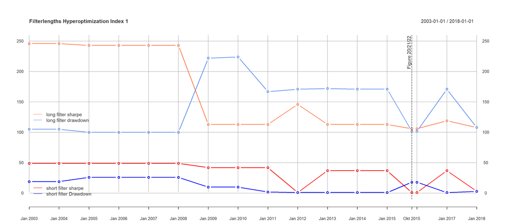

Hyperoptimization Index 1